# PEMFC Cathode GDL

1D model

## Introduction

PEMFC는 작동 온도가 낮고 가스를 습윤시켜 공급하기 때문에, **Flooding 현상**이 자주 발생한다. 특히 Cathode의 GDL에 물이 고이면 산소가 반응 영역으로 들어가는 길을 막아 전지 성능이 떨어진다.

연료전지 내부의 Flooding을 방지하고 산소 공급을 원활하게 하기 위해, **GDL의 발수성(접촉각), 공극률, 두께 및 운전 조건이 성능에 미치는 영향**을 1D 다상 혼합물($M^2$) 모형으로 분석한 논문이다.

## Assumptions

1. 시스템은 **등온 및 정상 상태**이다.
2. 기체상은 이상기체 혼합물이며 액체상에 용해되지 않는다.
3. 촉매층(Catalyst Layer)은 무한히 얇으며 전기화학 반응이 발생하는 경계면 취급한다.
4. 전해질 막(Membrane)은 액체 물로 완전히 수화되어 있다.

## 다상 혼합물($M^2$) 기초 모형

### 혼합물 밀도 ($\rho$)

$$\rho = \rho_l s + \rho_g (1 - s)$$
*(여기서 $s$는 액체 물 포화도, $\rho_l$은 액체 밀도, $\rho_g$는 기체 밀도)*

### 액체상 질량 플럭스 ($j_l$, 모세관력 유동)

$$j_l = \frac{K \lambda_l \lambda_g}{\nu} \nabla P_c$$
*(중력 효과 무시, 절대 투과율 $K$, 상 이동성 $\lambda$, 동점도 $\nu$, 모세관 압력 $P_c$ 반영)*

## 모세관 압력 및 Leverett $J(s)$ 함수

### 모세관 압력 ($P_c$)

$$P_c = \sigma \cos(\theta_c) \left( \frac{\epsilon}{K} \right)^{1/2} J(s)$$

### Leverett $J(s)$ 함수 (소수성 GDL: $90^\circ < \theta_c < 180^\circ$)

$$J(s) = 1.417s - 2.12s^2 + 1.263s^3$$

*(접촉각 $\theta_c$, 표면장력 $\sigma$, 기공률 $\epsilon$)*

## 혼합물 연속 방정식 (Continuity Equation)

### GDL 내 질량 보존

- ε $\frac{∂ρ}{∂t}$+∇·(ρu) = 0
- 다상 혼합물($M^2$) 모형에 의해 기체상과 액체상을 단일 혼합물 유속 $\mathbf{u}$로 표현.
- 정상 상태 조건에서 GDL을 통과하는 전체 질량 플럭스는 보존됨

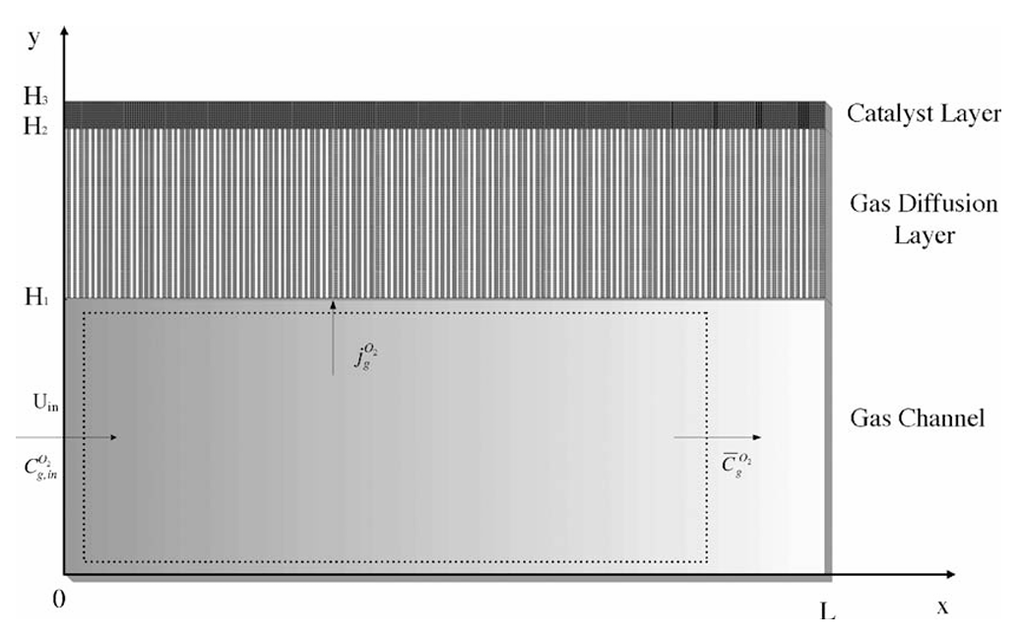

## 지배 방정식 1: 물 보존 방정식

수분 생성/이동량과 모세관력에 의한 이송의 균형 방정식:

$$\left( \lambda_l + \lambda_g \frac{\rho_v^{\text{H}_2\text{O}}}{\rho_g} \right) \left[ -\frac{I}{2F}(1+2\alpha)M^{\text{H}_2\text{O}} + \frac{I}{4F}M^{\text{O}_2} \right] + \left(1 - \frac{\rho_v^{\text{H}_2\text{O}}}{\rho_g}\right) j_l = -\frac{I}{2F} M^{\text{H}_2\text{O}} (1+2\alpha)$$

- $I$: 전류밀도, $F$: 패러데이 상수 - $\alpha$: 막을 통한 순 수분 이동 계수 (Net water transport coefficient) - 모세관력에 의한 물 배출 플럭스 $j_l$이 포화도 $s$의 분포를 결정함

## 지배 방정식 2: 산소 보존 방정식

대류, 모세관력 이송 및 확산을 포함하는 산소 수송 방정식:

$$\lambda_g C_g^{\text{O}_2} \left[ -\frac{I}{2F}(1+2\alpha)M^{\text{H}_2\text{O}} + \frac{I}{4F}M^{\text{O}_2} \right] - C_g^{\text{O}_2} j_l - \left[ \epsilon \rho_g (1-s) D_g^{\text{O}_2, \text{eff}} \nabla C_g^{\text{O}_2} \right] = \frac{I}{4F} M^{\text{O}_2}$$

### 유효 확산 계수 (Bruggeman 보정)

$$D_g^{\text{O}_2, \text{eff}} = [\epsilon(1-s)]^\tau D_g^{\text{O}_2}$$
*(액체 물이 차오름($s \uparrow$)에 따라 유효 기공률이 줄어들어 산소 확산 계수가 감소함을 표현)*

## Boundary Conditions

유동 채널과 GDL 경계면($y=H_1$)에서의 조건:

### 1. 물 포화도 경계 조건

채널 경계에서는 액체 물이 체류하지 않고 즉시 제거된다고 가정
$$s = 0 \quad \text{at } y = H_1$$

### 2. 산소 농도 경계 조건

채널 내 유속 $u_{in}$ 및 대류 물질전달계수 $h_m$을 고려한 외부 공급 농도
$$C_g^{\text{O}_2}\Big|_{y=H_1} = C_{g,in}^{\text{O}_2} - \frac{M^{\text{O}_2} I}{4 \rho_g^{\text{air}} F} \left( \frac{1}{h_m} + \frac{L}{u_{in} H_1} \right)$$

## 셀 성능 평가 (전압 및 전류 밀도)

### Tafel 방정식

$$I = (1-s) I_{\text{ref}} \frac{C_g^{\text{O}_2}\Big|_{y=H_2}}{C_{g,\text{ref}}^{\text{O}_2}} \exp\left( \frac{\alpha_c F}{RT} \eta \right)$$
*(액체 물 피복으로 인한 촉매 반응 활성 면적 감소 효과를 $(1-s)$ 인자로 반영)*

### 셀 출력 전압 ($V$)

$$V = V_{oc} - \eta - \eta_{\text{ohm}}, \quad \eta_{\text{ohm}} = \frac{I H_m}{\sigma_m}$$

$$\text{물 누적}(s \uparrow) \;\rightarrow\; \text{산소 확산 저하 및 반응 면적 감소} \;\rightarrow\; \text{한계 전류 밀도 감소}$$

## 핵심 변수

### ① 발수성 (Contact Angle, $\theta_c$)

- GDL이 소수성($\theta_c > 90^\circ$)일수록 모세관력에 의해 액체 물 배출 향상
- $\theta_c$가 $91^\circ \rightarrow 100^\circ$ 증가 시 물 포화도($s$) 약 54.7% 감소하며 성능 급증
- $100^\circ$ 이상에서는 물 배출 개선 효과가 점차 둔화됨

### ② 공극률 (Porosity, $\epsilon$)

- 공극률이 높을수록 유효 확산 계수($D_g^{\text{O}_2, \text{eff}}$)가 커져 산소 공급 원활
- 고전류밀도 영역에서 플러딩으로 인한 농도 손실(Concentration Loss) 방지에 핵심적 역할

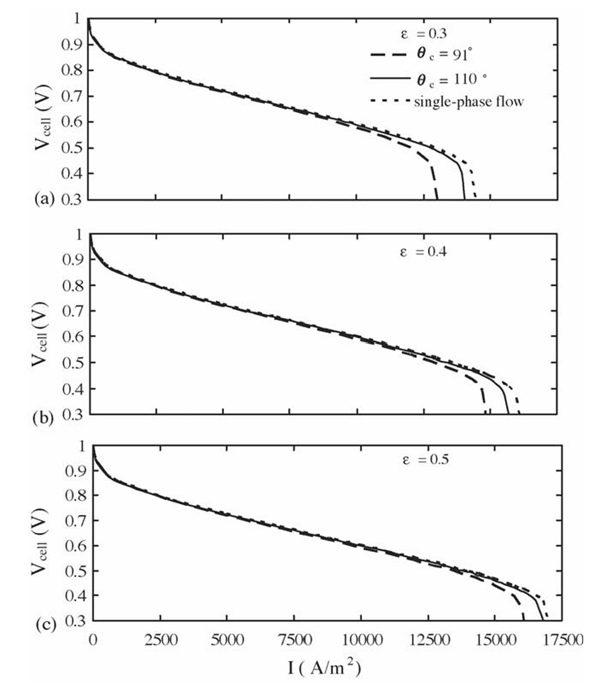

## 핵심 변수

### ③ GDL 두께 (Thickness, $H_2 - H_1$)

- GDL이 두꺼울수록 수분 배출 저항 및 산소 이동 거리가 증가
- 두께가 늘어날수록 산소 결핍 현상이 일찍 발생하여 한계 전류 밀도 하락

### ④ 가스 유입 속도 (Inlet Velocity, $u_{in}$)

- 유속이 빠를수록 대류에 의한 산소 공급량이 늘어나 한계 전류 밀도 상승
- 저유속/저전류에서는 물 생성이 적어 단상(Single-phase) 모델과 차이가 적지만, 고유속/고전류 밀도일수록 2상 유체(Two-phase) 해석이 필수적임

### ⑤ 채널 길이 (Gas Channel Length, $L$)

- 채널이 길어질수록 반응에 의한 산소 소모로 하류(Downstream) 산소 농도 급감
- 채널 길이가 너무 긴 경우, 물에 의한 플러딩 이전에 산소 결핍 자체로 인해 셀 전체 성능이 급격히 저하됨

## 시뮬레이션 변수 체계 정리

### 1. 제어(조작) 변수

- GDL 접촉각 ($\theta_c$)
- GDL 기공률 ($\epsilon$)
- GDL 두께 ($H_2 - H_1$)
- 가스 유입 속도 ($u_{in}$)
- 채널 길이 ($L$)

### 2. 상태(종속) 변수

- 액체 물 포화도 ($s$)
- 산소 농도 ($C_g^{\text{O}_2}$)
- 과전압 ($\eta$)
- $V\text{-}I$ 분극 곡선
- 한계 전류 밀도

### 3. 통제(고정) 변수

- 셀 작동 온도 ($T$)
- 작동 압력 ($P$)
- Membrane 두께 및 전도도
- 촉매 물리량 ($I_{\text{ref}}$ 등)

## 최종 결론

GDL 내 2상 유동 수송 현상을 수학적 모형으로 구현한 뒤, 플러딩을 찾는다.

이 논문들에서 나온 실험 그래프들을 보면 GDL의 발수성(접촉각 $\ge 100^\circ$)과 공극률을 높이고, 두께를 얇게 설계하며, 반응물 공급 유속을 확보할수록 플러딩이 줄어들어 물 포화도 s가 감소하고, 산소 공급이 원활해져 최종 VI 성능이 올라간다는 설계를 확인할 수 있다.성능 저하의 원인이 항상 Flooding은 아니며, 산소 결핍으로 인한 농도 손실이 먼저 발생할 수 있음도 고려해야 한다.

액상 $H_2O$ —> GDL 공극 차단 —| 산소 수송 —> 전지 성능  
(여기가 증가) ——————————–————| (여기가 저하)